# Performance Statistics

Rebuilding Time

L Kell

13 December, 2023

When conducting Management Strategy Evaluation objective need to be agreed and then quantified in the form of statistics known as **Performance Statistics**.

Ensuring sustainability requires preventing the stock from becoming overfished, so there is a low probability of compromising productivity. Therefore, many fishery management bodies define a biomass limt reference ($B_{lim}$) above which the stock should be maintained with high probability. Biomass limits should be based exclusively on the biology of the stock and its resilience to fishing pressure. They should not consider economic factors, as the objective is to reduce risks from a biological perspective, and must integrate dynamic processes such as growth, fecundity, recruitment, mortality and connectivity into indices for exploitation level and spawning reproductive potential.

A way of doing this consistently across stocks and model assumptions is to calculate the rebuilding relative to generation time for a depleted stock to a target level, e.g. the biomass that will support the maximum sustainable yield ($B_{MSY}$). For example as required for depleted fisheries in the [United States](https://www.federalregister.gov/documents/2016/10/18/2016-24500/magnuson-stevens-act-provisions-national-standard-guidelines). This is also consistent with the IUCN Red List of Threatened Species (Hilton-Taylor and Brackett 2000), which uses generation time as a measure of population decline, as it allows the same criteria to be used for species with extremely different life spans (Mace et al. 2008).

Therefore, as a performance statistic for safety we propose the biomass from which a stock can recover to $B_{MSY}$ within a given time scale and level of fishing mortality ($B_{rebuild}$). The details of which determine the level of risk and so are a management decision. For example, if the management objective is that a depleted stock should recover within a generation time with zero fishing, the corresponding depletion level provides the limit reference point.

In an MSE the 5% level could be used for evaluation, i.e. a strategy is only successful if it keeps a stock above $B_{rebuild}$ with a 95% probability.

## Example using ‘FLBRP’

For a stock the ‘FLBRP’ object can be derived, this holds the expected values for the mortality, selectivity, mass, marurity-at-age, and the stock recruitment relationship, and can be used to calculate the expected, i.e. equilibrium values of biomass for any given level of fishing mortality.

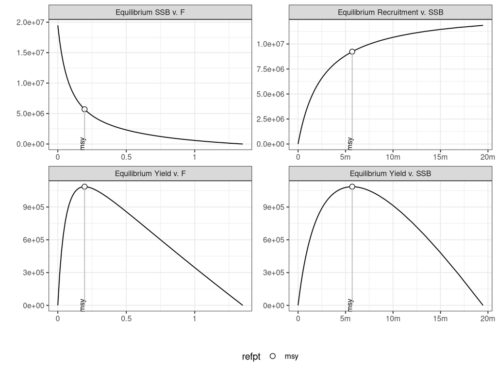

**Figure 1** Equilibrium curves showing estimates of SSB, recruitment yield and F.

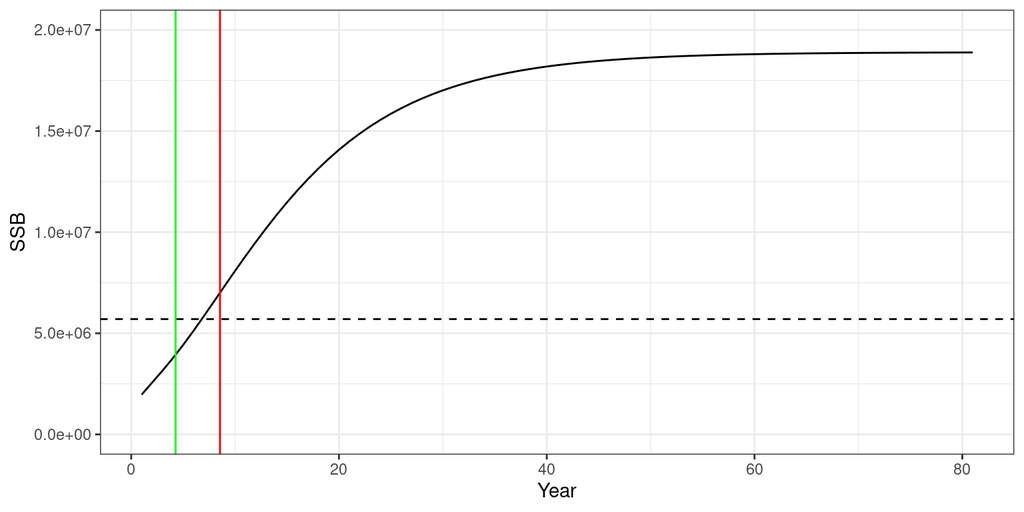

**Figure 2** Recovery from depletion, vertical lines are half (green) and one (red) generation time

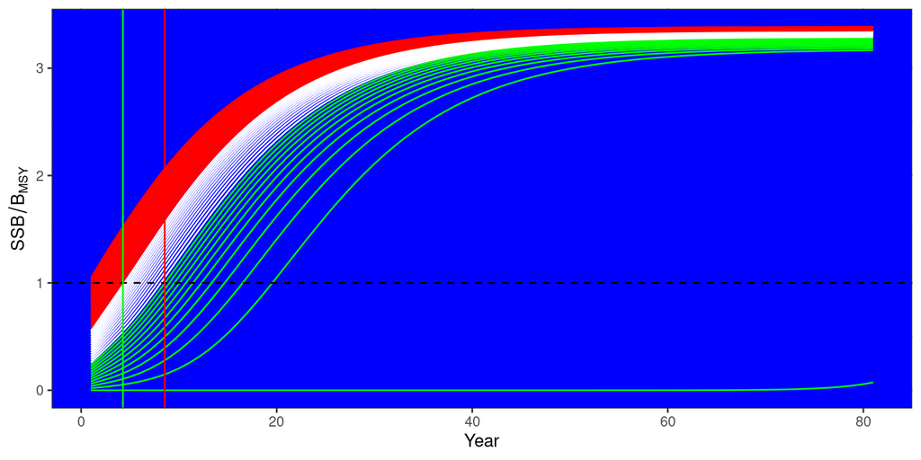

If the management objective is in the case of stock depletion is to close the fishery to recover a stock in a generation time then the biomass limit that should be avoided with high probability is 25% of $B_{MSY}$. If fishing is still to be allowed under recovery then the biomass limit will have to be higher.

As a performance statistic you could then say there must be a 95% prob that you can rebuild within a given fraction of a generation time with F=0.

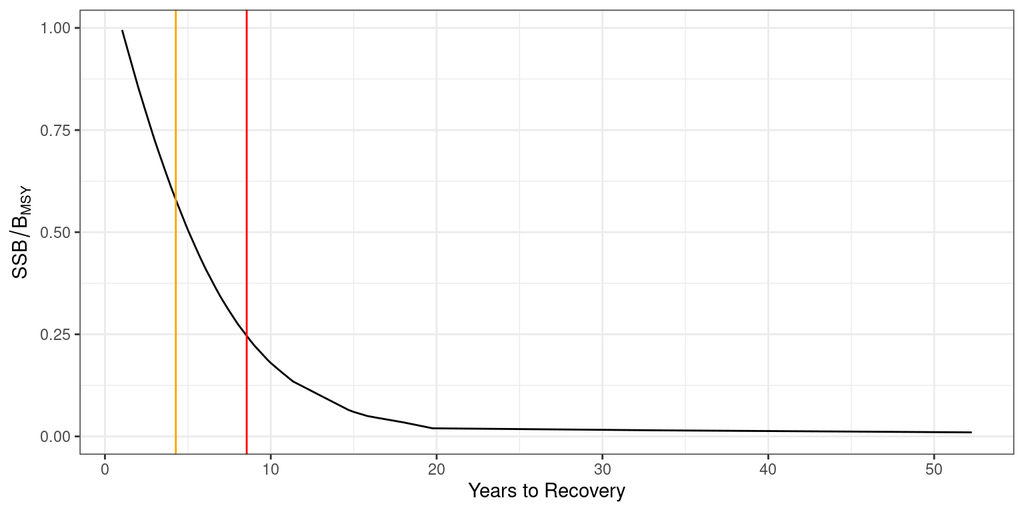

### Impact of M and the SRR

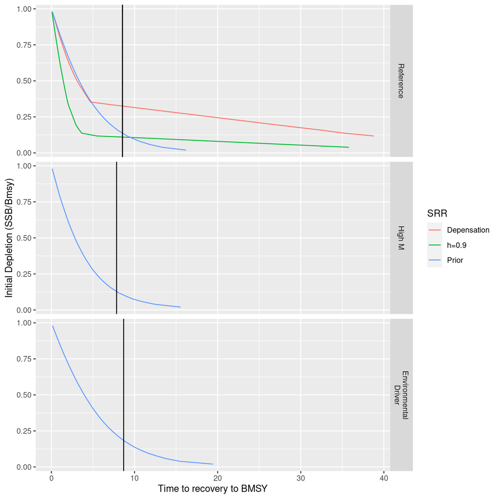

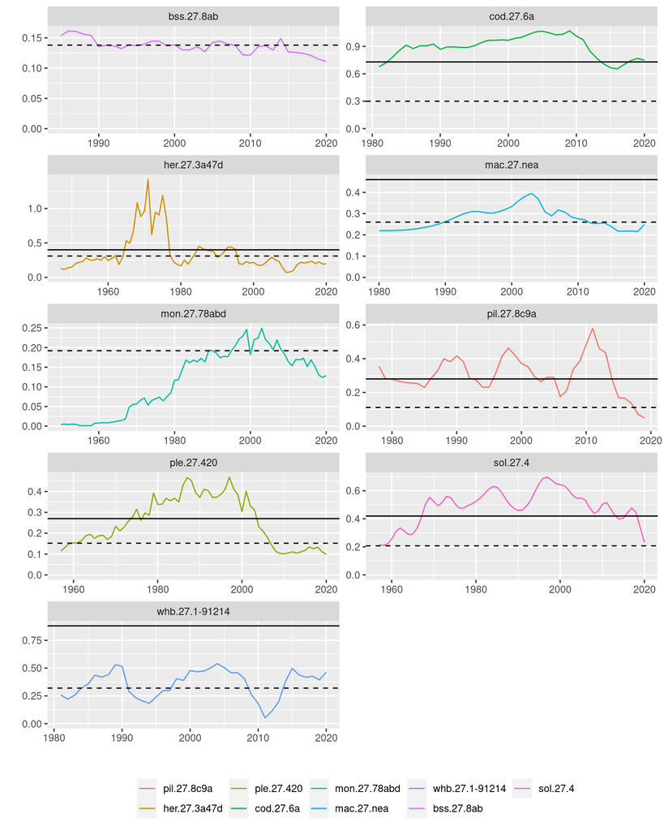

**Figure 5** Time series of fishing mortality, with $F_{MSY}$ (dashed) and $F_{lim}$ (solid).

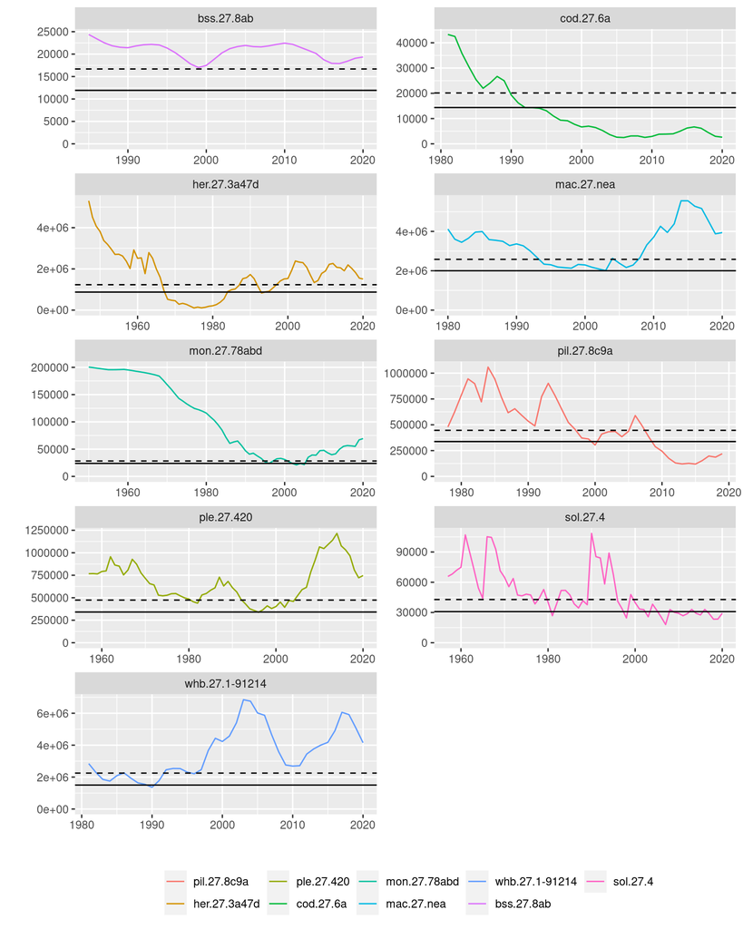

**Figure 6** Time series of SSB, with $B_{MSY}$ (dashed) and $B_{lim}$ (solid).

[output not shown]

[output cut: 106 more lines]

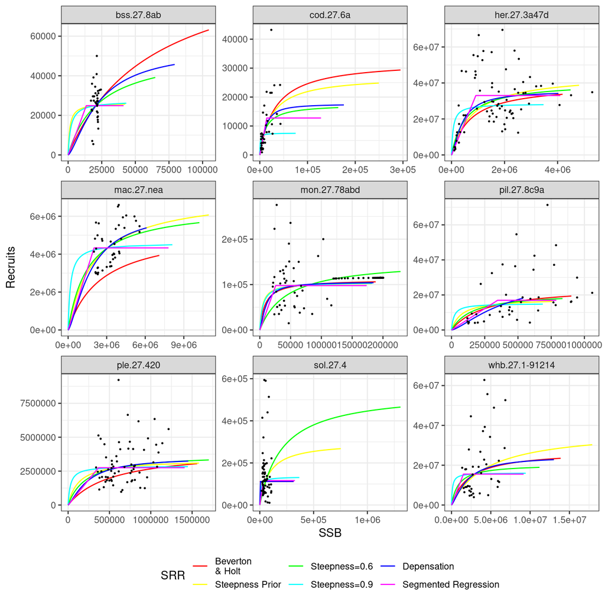

**Figure 7**

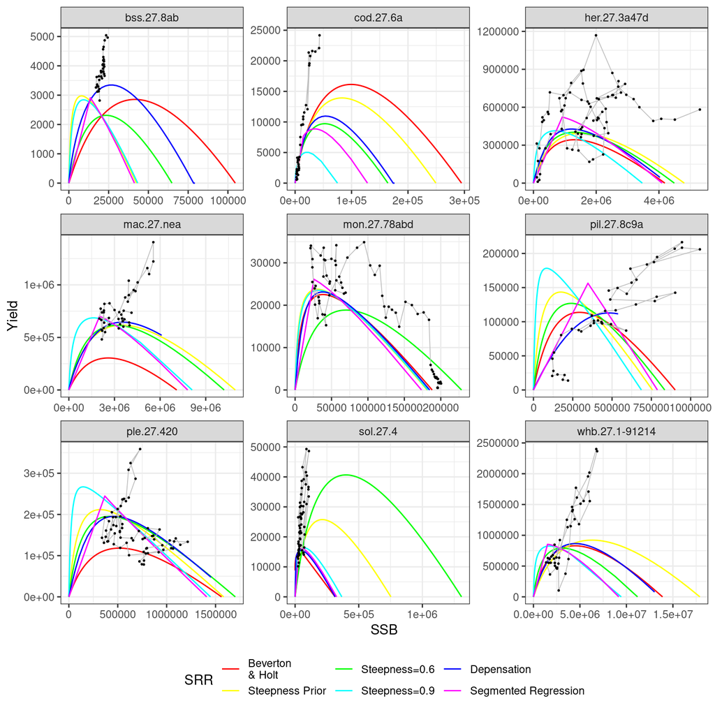

**Figure 8**

[output not shown]

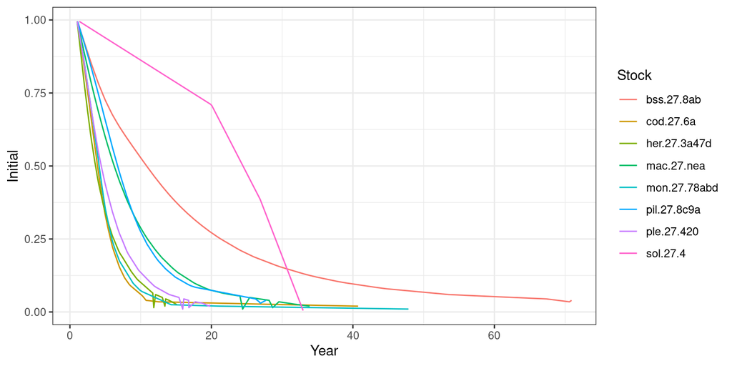

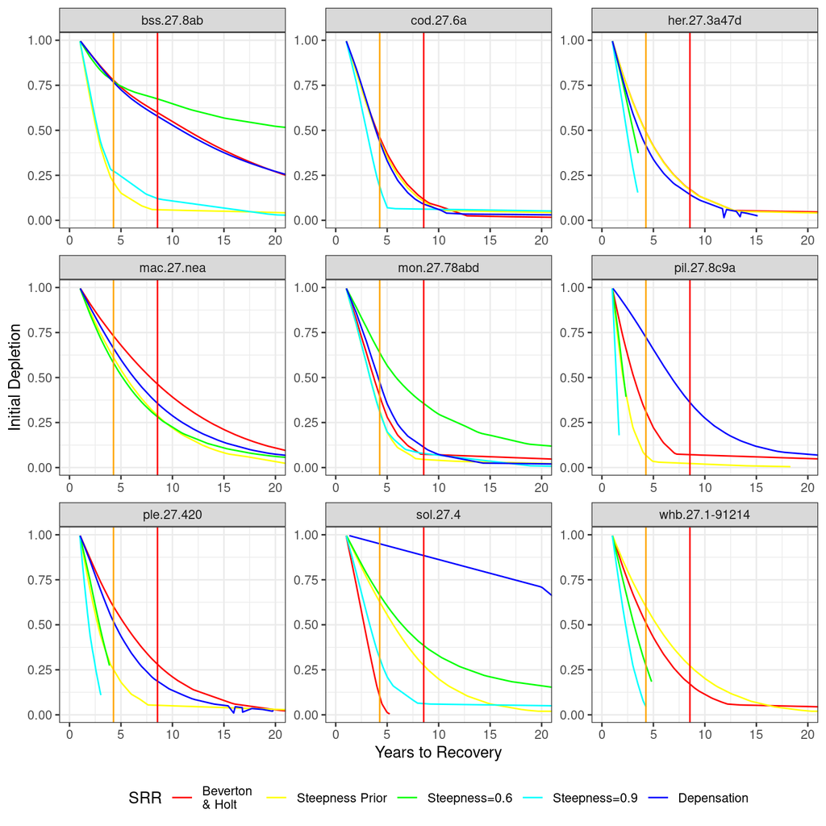

Table 1: Ratio between ICES and scenario $B_{MSY}$

| .id | Beverton & Holt | Steepness Prior | Steepness=0.6 | Steepness=0.9 | Depensation |
| --- | --- | --- | --- | --- | --- |
| bss.27.8ab | 0.455 | 2.320 | 0.811 | 2.068 | 0.689 |
| cod.27.6a | 0.381 | 0.440 | NA | 1.565 | 0.696 |
| her.27.3a47d | 1.216 | 1.063 | 1.192 | 2.252 | 1.266 |
| mac.27.nea | 1.027 | 0.751 | 0.854 | NA | 0.741 |
| mon.27.78abd | 0.987 | 1.225 | 0.532 | 1.155 | 1.035 |
| pil.27.8c9a | 2.267 | 3.949 | 2.838 | 8.067 | 1.378 |
| ple.27.420 | 1.031 | 1.610 | 1.261 | 3.570 | 1.161 |
| sol.27.4 | 1.767 | 0.341 | 0.180 | 0.956 | 1.635 |
| whb.27.1-91214 | 0.771 | 0.544 | 1.125 | 2.096 | NA |

Table 2: Rebuilding Time

| .id | Beverton & Holt | Steepness Prior | Steepness=0.6 | Steepness=0.9 | Depensation |
| --- | --- | --- | --- | --- | --- |
| bss.27.8ab | 19.245 | -0.365 | 22.261 | -0.013 | 12.963 |
| cod.27.6a | 7.882 | 7.181 | NA | 2.606 | 5.560 |
| her.27.3a47d | 2.922 | 3.515 | 2.435 | 0.340 | 2.451 |
| mac.27.nea | 3.673 | 4.735 | 3.662 | NA | 5.484 |
| mon.27.78abd | 3.003 | 2.037 | 8.885 | 2.244 | 3.187 |
| pil.27.8c9a | 0.508 | -0.823 | -0.153 | -1.346 | 4.650 |
| ple.27.420 | 3.675 | 0.884 | 1.740 | -1.038 | 2.671 |
| sol.27.4 | 1.872 | 11.410 | 50.087 | 3.746 | 20.190 |
| whb.27.1-91214 | 5.998 | 9.241 | 3.166 | 1.211 | NA |

# References

Hilton-Taylor, Craig, and David Brackett. 2000. “2000 IUCN Red List of Threatened Species.”

Mace, Georgina M, Nigel J Collar, Kevin J Gaston, CRAIG Hilton-Taylor, H Resit Akçakaya, NIGEL Leader-Williams, Eleanor Jane Milner-Gulland, and Simon N Stuart. 2008. “Quantification of Extinction Risk: IUCN’s System for Classifying Threatened Species.” *Conservation Biology* 22 (6): 1424–42.